# Random commitment model qualitative comparison

# Changes

- In the human data, error trials (which the model never predicts) are excluded.
- In the model, strength is now proportional to $\log(p)$—previously it was just $p$. The motivation for this is that reaction time in a single cue recall task is proportional to $1 / p$, which implies $\log(p) = C - \log(t)$ for some unknown constant $C$. Because our human strength measure is in units of $\log(t)$, it makes sense for the model strength to be proportional $\log(p)$.
- We also add Gaussian noise to the model strength to account for the fact that the human strength measure is very noisy. Ideally we would have a more principled way to do this (based on a generative model).
- New random model: At the beginning of the trial, the “Random commitment” model samples the maximum number of fixations from the empirical distribution. Each fixation duration is drawn from the empirical distribution of non-final fixations. When the maximum number of fixations has been reached, the model stays on the currently fixated cue until the target is recalled or the trial time limit is reached (15 seconds).

# Main Results

## Probability of remembering first word

As a sanity check, we first ask if our memory strength index predicts participants choices about which image to recall. We operationalize memory strength as the within-participant Z-scored, mean log 2AFC RT (that’s a mouthful!) If this index tracks memory strength, we should see that the probability that a target is chosen for recollection should depend on the difference in “strength” between the two cues.

Note: For the model, strength corresponds to the $p$ parameter. Here, we Z-score $\log(p)$ to put it in roughly the same units. The motivation for this is that reaction time in a single cue recall task is proportional to $1 / p$, which implies $\log(p) = C - \log(t)$ for some unknown constant $C$. Because our human strength measure is in units of $\log(t)$, it makes sense for the model strength to be proportional $\log(p)$.

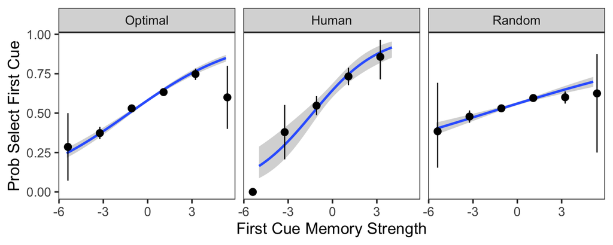

```r
df %>%
    ggplot(aes(rel_strength, as.numeric(choose_first))) +
    geom_smooth(method = "glm", method.args = list(family = "binomial"), formula=y~x) +
    stat_summary_bin(fun.data=mean_cl_boot, bins=5) +
    facet_wrap(~name) +
    labs(x="First Cue Memory Strength", y="Prob Select First Cue")
```

```r
human %>%
    lmer(choose_first ~ rel_strength + (rel_strength|wid), data=.) %>% summ
```

| Fixed Effects | Fixed Effects Est. | Fixed Effects S.E. | Fixed Effects t val. | Fixed Effects d.f. | Fixed Effects p |
| --- | --- | --- | --- | --- | --- |
| (Intercept) | 0.634 | 0.030 | 21.307 | 62.124 | 0.000 |
| rel_strength | 0.092 | 0.015 | 6.243 | 185.128 | 0.000 |

p values calculated using Satterthwaite d.f.

```r
# lmer(choose_first ~ strength_first + strength_second + (strength_first + strength_second |wid), data=X) %>% summ
```

Note: unless otherwise stated, all regression tables are maximal linear mixed effects models (random slopes and intercepts) applied to the human data. Plotted regression lines are fixed effects only.

## Fixation proportion by relative memory strength

The simplest test of rational memory: do people spend more time looking at the cue that they have a stronger memory of? This analysis only considers trials where both cues are seen.

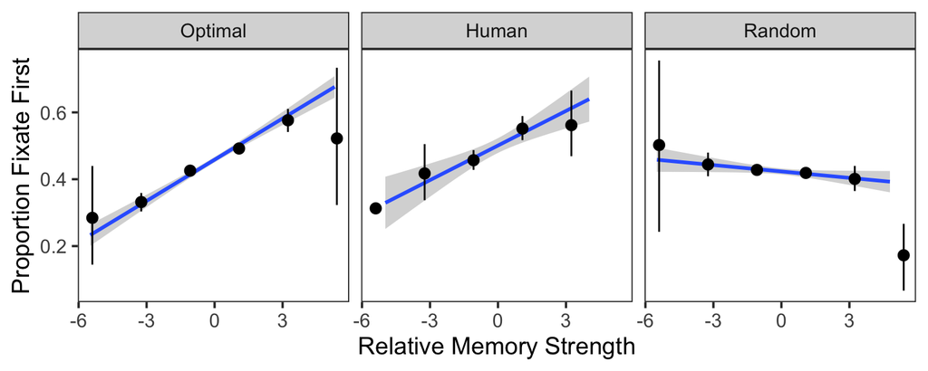

```r
df %>%
    filter(n_pres >= 2) %>%
    ggplot(aes(rel_strength, prop_first)) +
    geom_smooth(method = "lm", formula="y~x") +
    stat_summary_bin(fun.data=mean_cl_boot, bins=5) +
    facet_wrap(~name) +
    labs(x="Relative Memory Strength", y="Proportion Fixate First")
```

```r
X = df %>% filter(n_pres >= 2 & name == "Human")
lmer(choose_first ~ rel_strength + (rel_strength|wid), data=X) %>% summ
```

| Fixed Effects | Fixed Effects Est. | Fixed Effects S.E. | Fixed Effects t val. | Fixed Effects d.f. | Fixed Effects p |
| --- | --- | --- | --- | --- | --- |
| (Intercept) | 0.391 | 0.032 | 12.194 | 50.714 | 0.000 |
| rel_strength | 0.111 | 0.018 | 6.054 | 144.294 | 0.000 |

p values calculated using Satterthwaite d.f.

They do! 🎉 But hold on, there’s a small but significant effect in the random model. What’s going on there?

### Last fixation effect

People remember the thing they look at last 94% of the time. In value-based decision making, it has been suggested that this last-fixation effect could explain away what looks to be evidence for adaptive attention allocation. Briefly, the last fixation is correlated with both fixation proportion and relative strength, and this could be entirely driving the correlation between strength and fixation proportion. See here for a more thorough explanation.

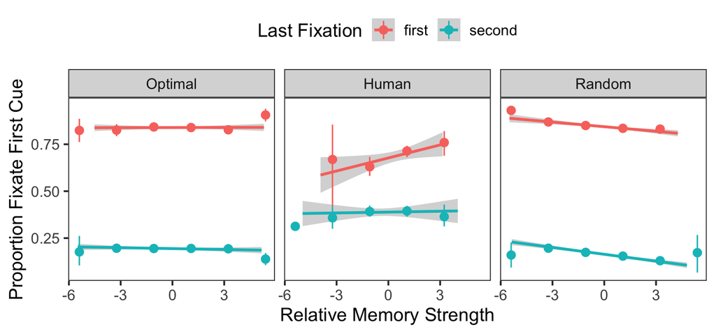

```r
df %>%
    filter(n_pres >= 2) %>%
    ggplot(aes(rel_strength, prop_first, color=last_pres)) +
    geom_smooth(method="lm") +
    stat_summary_bin(fun.data=mean_cl_boot, bins=5) +
    facet_wrap(~name) +
    theme(legend.position="top") +
    labs(x="Relative Memory Strength", y="Proportion Fixate First Cue", color="Last Fixation")
```

```r
X = df %>% filter(n_pres > 1 & name == "Human")
lmer(prop_first ~ rel_strength * last_pres + (rel_strength * last_pres | wid), data=X) %>% summ
```

| Fixed Effects | Fixed Effects Est. | Fixed Effects S.E. | Fixed Effects t val. | Fixed Effects d.f. | Fixed Effects p |
| --- | --- | --- | --- | --- | --- |
| (Intercept) | 0.670 | 0.021 | 31.551 | 39.055 | 0.000 |
| rel_strength | 0.028 | 0.010 | 2.896 | 36.587 | 0.006 |
| last_pressecond | -0.276 | 0.027 | -10.038 | 43.502 | 0.000 |
| rel_strength:last_pressecond | -0.028 | 0.012 | -2.342 | 57.030 | 0.023 |

p values calculated using Satterthwaite d.f.

The effect of relative memory strength on fixation proportion is a lot weaker when we control for the effect of the last fixation, but it remains significant. However, it’s *not* significant in the optimal model (regression not shown).

## First fixation duration

Given the complications with the total fixation duration, the duration of the first fixation is potentially a more reliable cue. Previously the model made a strong prediction here, but with the new parameters, this is no longer the case.

Consider only the trials with more than one fixation. Do participants switch away from the first image more quickly when they have a worse memory of it?

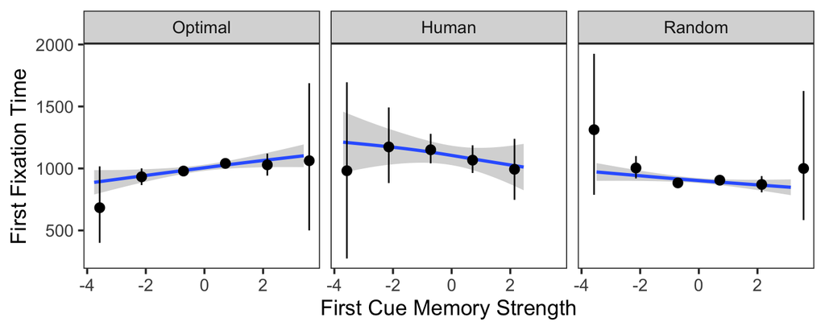

```r
df %>%
    filter(n_pres >= 2) %>%
    ggplot(aes(strength_first, first_pres_time)) +
    # geom_smooth(method="lm") +
    geom_smooth() +
    stat_summary_bin(fun.data=mean_cl_boot, bins=5) +
    facet_wrap(~name) +
    labs(x="First Cue Memory Strength", y="First Fixation Time")
```

```r
human %>%
    filter(n_pres >= 2) %>%
    lmer(first_pres_time ~ strength_first + (strength_first|wid), data=.) %>% summ
```

| Fixed Effects | Fixed Effects Est. | Fixed Effects S.E. | Fixed Effects t val. | Fixed Effects d.f. | Fixed Effects p |
| --- | --- | --- | --- | --- | --- |
| (Intercept) | 1295.693 | 101.062 | 12.821 | 45.052 | 0.000 |
| strength_first | 15.744 | 25.669 | 0.613 | 174.018 | 0.540 |

p values calculated using Satterthwaite d.f.

Not a lot of information here.

## Second fixation duration

We can do a similar analysis for the second fixation duration. In this case, however, the duration may depend on the strength of both the first and second cues. As before, we exclude final fixations in this plot (i.e. excluding trials less than three fixations).

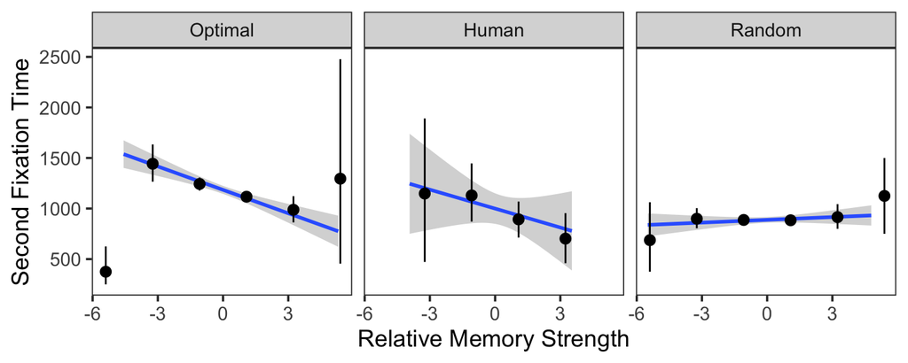

```r
df %>%
    filter(n_pres >= 3) %>%
    ggplot(aes(rel_strength, second_pres_time)) +
    geom_smooth(method="lm") +
    stat_summary_bin(fun.data=mean_cl_boot, bins=5) +
    facet_wrap(~name) +
    labs(x="Relative Memory Strength", y="Second Fixation Time")
```

```r
X = human %>%
     filter(n_pres >= 3)

X %>% lmer(second_pres_time ~ rel_strength + (rel_strength|wid), data=.) %>% summ
```

| Fixed Effects | Fixed Effects Est. | Fixed Effects S.E. | Fixed Effects t val. | Fixed Effects d.f. | Fixed Effects p |
| --- | --- | --- | --- | --- | --- |
| (Intercept) | 1090.476 | 131.081 | 8.319 | 35.848 | 0.000 |
| rel_strength | -89.675 | 49.620 | -1.807 | 45.024 | 0.077 |

p values calculated using Satterthwaite d.f.

```r
# X %>% lmer(second_pres_time ~ strength_first + strength_second + (strength_first + strength_second|wid), data=.) %>% summ
```

The model makes a strong prediction here, and I don’t think it is confounded by anything. Previously, we had a significant effect here in the human data. But excluding the incorrect trials pushed the p up a bit. It does seem plausible that the effect is there though.

## Third fixation duration

Same thing for the third fixation.

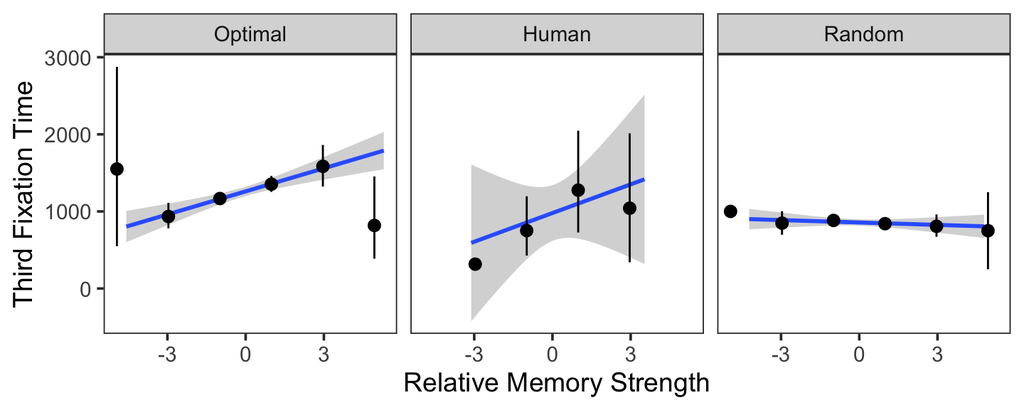

```r
df %>%
    filter(n_pres >= 4) %>%
    ggplot(aes(rel_strength, third_pres_time)) +
    geom_smooth(method="lm") +
    stat_summary_bin(fun.data=mean_cl_boot, bins=5) +
    facet_wrap(~name) +
    labs(x="Relative Memory Strength", y="Third Fixation Time")
```

```r
human %>%
    filter(n_pres >= 4) %>%
    lmer(third_pres_time ~ rel_strength + (rel_strength|wid), data=.) %>% summ
```

| Fixed Effects | Fixed Effects Est. | Fixed Effects S.E. | Fixed Effects t val. | Fixed Effects d.f. | Fixed Effects p |
| --- | --- | --- | --- | --- | --- |
| (Intercept) | 1366.718 | 354.319 | 3.857 | 16.112 | 0.001 |
| rel_strength | 464.200 | 170.497 | 2.723 | 10.261 | 0.021 |

p values calculated using Satterthwaite d.f.

I previously thought this could be due to selection effects, but I’m not exactly sure what those would be. I think we can interpret this result as evidence as long as we get a null result in a convincing random model.

```r
make_fixations = function(df) {
    df %>%
        ungroup() %>%
        filter(n_pres >= 1) %>%
        select(name, rel_strength, presentation_times, n_pres) %>%
        mutate(
            trial = row_number(),
            strength_diff = cut(abs(rel_strength),
                                c(0, 0.35, 1.25, 10),
                                # quantile(abs(rel_strength), c(0, 0.2, 1.),  na.rm = T),
                                labels=c("small", "moderate", "large"),
                                ordered=T)
        ) %>%
        unnest_longer(presentation_times, "duration", indices_to="presentation") %>%
        mutate(
            last_fix = as.numeric(presentation == n_pres),
            fix_first = presentation %% 2,
            fix_stronger = as.numeric(fix_first == (rel_strength > 0)),
            # duration = if_else(name == "Human", as.integer(duration), as.integer(duration * 250)),
        )
}

long = df %>%
    group_by(name) %>%
    slice_sample(n=2000) %>%
    make_fixations
```

## Final vs non-final duration

Longer final fixations suggest that people commit to a cue at some point. This is a cool finding because we see the opposite (shorter final fixations) in value-based and perceptual decisions, typically explained as the result of crossing a threshold cutting off the final fixations. The reason we see this in the optimal model is that the accumulation is not just to identify which target is more memorable and also to actually remembering it (perceptual and value-based decisions only have the former).

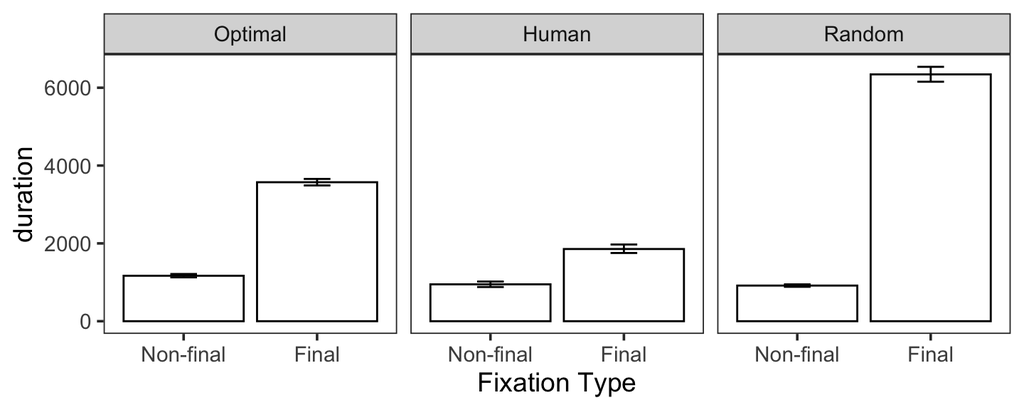

```r
long %>%
    # filter(name == "Human") %>%
    ggplot(aes(last_fix==1, duration)) +
    stat_summary(fun.data=mean_cl_boot, geom="bar", fill="white", color="black") +
    stat_summary(fun.data=mean_cl_boot, geom="errorbar", width=0.2) +
    facet_wrap(~name) +
    scale_x_discrete(name="Fixation Type", labels=c("Non-final", "Final"))
```

The random model result is interesting. The intention of the random commmitment model was to capture this exact phenomenon. But it seems to have way *over*-captured it. The reason this happens is (probably) that humans don’t actually randomly commit to a cue, but instead only commit when they are reasonably sure they will remember it. Also, any such commitment is probably not really a firm commitment. Anyway, what happens to this random model is that it commits too early or on a bad cue, and then it takes forever to remember it.

This might draw into question my decision to sample the commitment decision based on the empirical number-of-fixations distribution. The only alternative I can think of is to sample from a parametric distribution with some free parameter. Previously we discussed a probability of commiting on each fixation which is equivalent to an Exponential distribution. But we don’t have a good way to fit parameters…

## Time course

Finally, we can make a plot similar to the initial model prediction. How does the probability of fixating the more-memorable option change over the course of the trial? We normalize the x axis by the duration of the trial to reduce noise (it’s really messy with raw time).

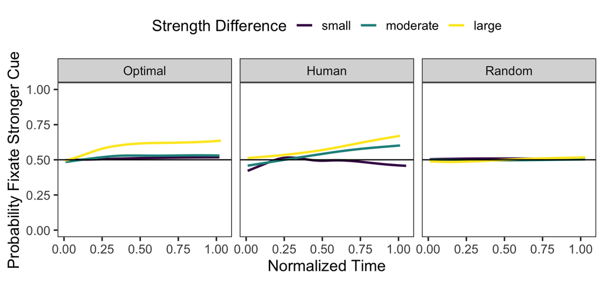

```r
normalized_timestep = function(long) {
    long %>%
        group_by(trial) %>%
        mutate(prop_duration = duration / sum(duration)) %>%
        ungroup() %>%
        mutate(n_step=round(prop_duration * 100)) %>%
        uncount(n_step) %>%
        group_by(trial) %>%
        mutate(normalized_timestep = row_number())
}

long = make_fixations(df)
nts = normalized_timestep(long)
nts %>%
    drop_na(strength_diff) %>%
    ggplot(aes(normalized_timestep/100, fix_stronger, group = strength_diff, color=strength_diff)) +
    geom_smooth(se=F) +
    ylim(0, 1) +
    facet_wrap(~name) +
    labs(x="Normalized Time", y="Probability Fixate Stronger Cue", color="Strength Difference") +
    geom_hline(yintercept=0.5) +
    theme(legend.position="top")
```

For the trials where one cue has a substantially stronger memory, we see a pretty reliable increase in probability of fixating the stronger cue over the course of the trial. It does look like people are slower on the uptake compared to the optimal model, suggesting that people might have some kind of “metacognitive lag”.

The optimal model prediction is a lot weaker than before because noise is added to the strength.

We no longer see a spike at the end in the Random model. I think this must be due to the commitment mechanism, but I have a hard time reconciling the null effect here with the substantial effect of cue strength on cue selection probability (Probability of remembering first word)

# Sanity checks for evidence accumulation

All these plots are testing really basic predictions of the evidence accumulation model, that is, effects that come out in the random model. They are all much weaker in humans than the model and some aren’t even significant. This suggests that we might need to make some adjustments to the base accumulation model, especially if we wanted to do any real model fitting.

## Reaction time by chosen strength

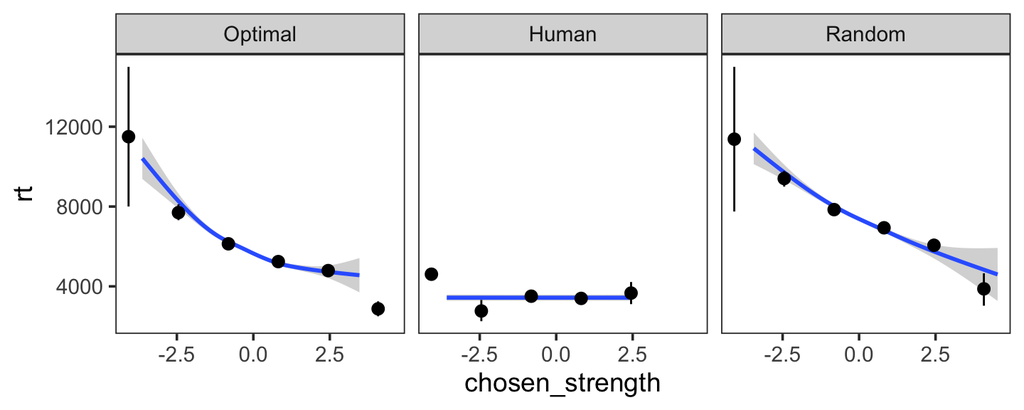

```r
df %>%
    ggplot(aes(chosen_strength, rt)) +
    geom_smooth() +
    stat_summary_bin(fun.data=mean_cl_boot, bins=5) +
    facet_wrap(~name)
```

```r
lmer(rt ~ chosen_strength + (chosen_strength|wid), data=human) %>% summ
```

| Fixed Effects | Fixed Effects Est. | Fixed Effects S.E. | Fixed Effects t val. | Fixed Effects d.f. | Fixed Effects p |
| --- | --- | --- | --- | --- | --- |
| (Intercept) | 3558.159 | 160.862 | 22.119 | 56.505 | 0.000 |
| chosen_strength | -155.152 | 66.243 | -2.342 | 39.697 | 0.024 |

p values calculated using Satterthwaite d.f.

## Last fixation duration by strength

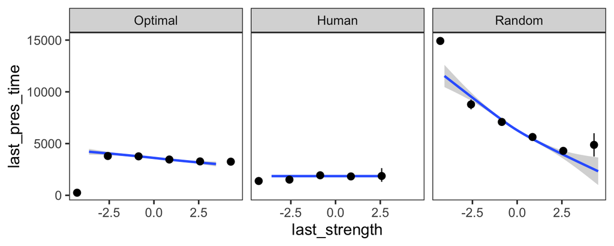

```r
X = df %>%
    filter(n_pres > 0) %>%
    mutate(
        last_pres_time = map_dbl(presentation_times, last),
        last_rel_strength = if_else(last_pres == "first", rel_strength, 1 - rel_strength),
        last_strength = if_else(last_pres == "first", strength_first, strength_second)
    )

X %>%
    ggplot(aes(last_strength, last_pres_time,)) +
    geom_smooth() +
    stat_summary_bin(fun.data=mean_cl_boot, bins=5) +
    facet_wrap(~name) +
    labs()
```

```r
X %>% filter(name == "Human") %>%
    lmer(last_pres_time ~ last_strength + (last_strength|wid), data=.) %>% summ
```

| Fixed Effects | Fixed Effects Est. | Fixed Effects S.E. | Fixed Effects t val. | Fixed Effects d.f. | Fixed Effects p |
| --- | --- | --- | --- | --- | --- |
| (Intercept) | 1875.914 | 102.409 | 18.318 | 61.339 | 0.000 |
| last_strength | -58.010 | 52.666 | -1.101 | 228.202 | 0.272 |

p values calculated using Satterthwaite d.f.

## Last fixation duration by strength and presentation

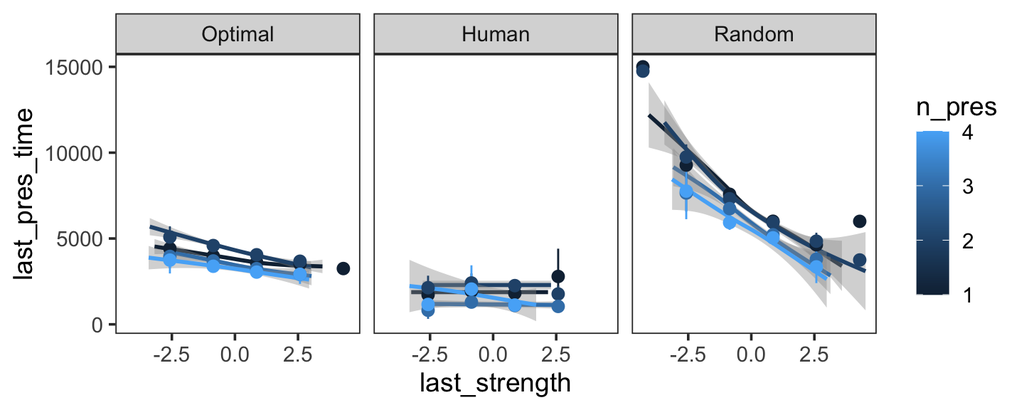

```r
X = df %>%
    filter(between(n_pres, 1, 4)) %>%
    mutate(
        last_pres_time = map_dbl(presentation_times, last),
        last_rel_strength = if_else(last_pres == "first", rel_strength, 1 - rel_strength),
        last_strength = if_else(last_pres == "first", strength_first, strength_second)
    )

X %>%
    ggplot(aes(last_strength, last_pres_time, group=n_pres, color=n_pres)) +
    geom_smooth() +
    stat_summary_bin(fun.data=mean_cl_boot, bins=5) +
    facet_wrap(~name) +
    labs()
```

```r
X %>% filter(name == "Human") %>%
    lmer(last_pres_time ~ last_strength * n_pres + (1|wid), data=.) %>% summ
```

| Fixed Effects | Fixed Effects Est. | Fixed Effects S.E. | Fixed Effects t val. | Fixed Effects d.f. | Fixed Effects p |
| --- | --- | --- | --- | --- | --- |
| (Intercept) | 2318.478 | 162.056 | 14.307 | 200.805 | 0.000 |
| last_strength | -2.120 | 116.763 | -0.018 | 454.605 | 0.986 |
| n_pres | -230.450 | 65.601 | -3.513 | 437.592 | 0.000 |
| last_strength:n_pres | -51.478 | 52.209 | -0.986 | 456.447 | 0.325 |

p values calculated using Satterthwaite d.f.

# Random stuff

## Timeout rate

[figure not shown]

```r
df %>%
    ggplot(aes(response_type == "timeout", ..prop..)) +
    geom_bar(group=0) +
    facet_wrap(~name)
```

## Reaction time

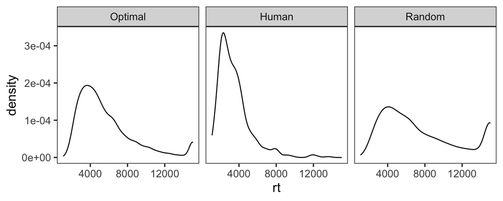

```r
df %>%
    ggplot(aes(rt)) +
    geom_density() +
    facet_wrap(~name)
```

## Number of fixations

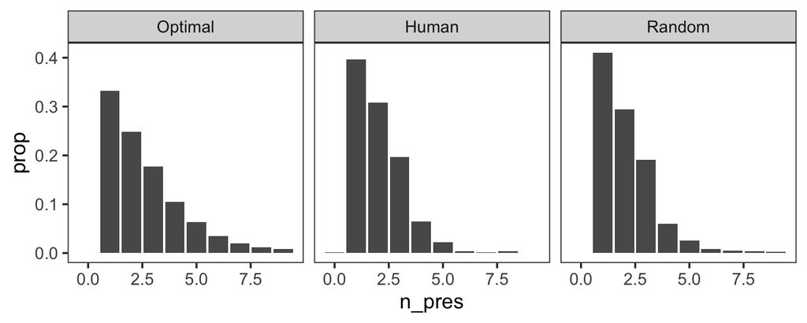

```r
df %>%
    filter(n_pres < 10) %>%
    ggplot(aes(n_pres, ..prop..)) +
    geom_bar() +
    facet_wrap(~name)
```

## Final fixation - relative strength

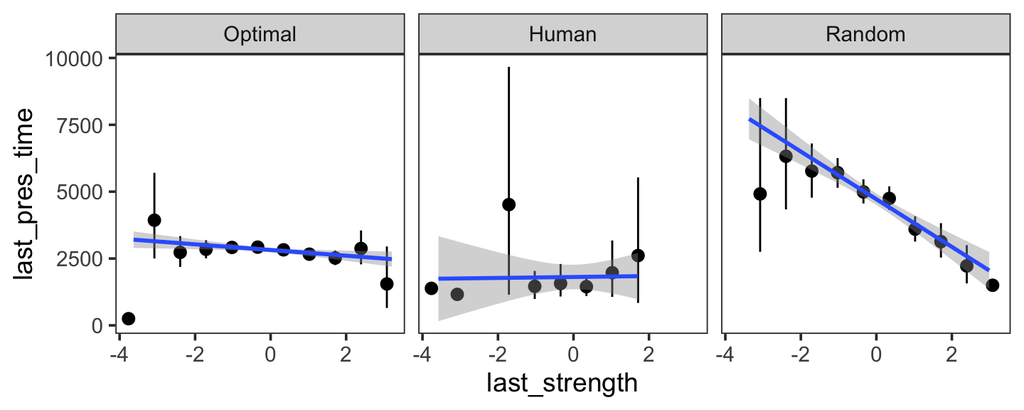

```r
X = df %>%
    filter(n_pres > 3) %>%
    mutate(
        last_pres_time = map_dbl(presentation_times, last),
        last_rel_strength = if_else(last_pres == "first", rel_strength, 1 - rel_strength),
        last_strength = if_else(last_pres == "first", strength_first, strength_second)
    )

X %>% ggplot(aes(last_strength, last_pres_time)) +
    stat_summary_bin(fun.data=mean_cl_boot, bins=10) +
    facet_wrap(~name) +
    geom_smooth(method='lm')
```

```r
X %>% lmer(last_pres_time ~ last_rel_strength + (last_rel_strength|wid), data=.) %>% summ
```

| Fixed Effects | Fixed Effects Est. | Fixed Effects S.E. | Fixed Effects t val. | Fixed Effects d.f. | Fixed Effects p |
| --- | --- | --- | --- | --- | --- |
| (Intercept) | 1842.821 | 427.786 | 4.308 | 17.415 | 0.000 |
| last_rel_strength | -134.021 | 223.912 | -0.599 | 13.859 | 0.559 |

p values calculated using Satterthwaite d.f.